# Vaccine allocation project results

GMB

2022-04-26

# 1 Introduction

This document brings together results from multiple model runs. It is intended to be re-run as the model is updated.

NOTE: The setting for this run is: SLE

**Focus questions:**

- What impact will the existing vaccination plan have on morbidity and mortality?
- What impact can be achieved under different levels of vaccine coverage?
- What are the potential benefits of expanding the immunisation schedule to include children?

**Overarching assumptions**

Unless otherwise specified, key model parameters in this run are:

| Variable | Value | Source |
| --- | --- | --- |
| Circulating strain | omicron |  |
| Length of model run | 52 |  |
| Current vaccine coverage | dose one: 21%; dose two: 14% | John Hopkins COVID-19 vaccination data |
| Current vaccine coverage target | 51.6% | Government target in COVAX documentation May 2021 |
| Proportion of population willing to be vaccinated | 0.88 | Survey estimating vaccine acceptance in January 2021 (Solis et al., 2021) |
| Daily capacity for vaccination (doses) | 11075 | Slightly lower than the pilot vaccination campaign October-November 2021 |
| Anticipated type of future vaccine doses | Johnson & Johnson | The Government of Sierra Leone has demonstrated a strong preference for this vaccine, negotiating with major donors, such as the Government of Italy, to change their donations of double-dose vaccines … |
| Waning of VE against acquisition | TRUE |  |
| Waning of VE against severe disease | FALSE |  |

**Other assumptions/limitations:**

- Linear roll-out of vaccines (Lowy Institute report and trends in the ACT do not support this)
- Vaccine effectiveness estimates last updated on the 14th of April 2022 from WHO live systematic review (https://view-hub.org/covid-19/effectiveness-studies)

**Next steps for noting:**

- update of infection- and vaccine-derived immunity
- sensitivity analysis
  - turning on/off waning of vaccine-derived immunity
  - simulating outbreaks of different strains
  - experimenting with different age-prioritisation strategies
  - other?

# 2 Impact of current program targets

Roll out of current program target (51.6% coverage) during or prior to an outbreak:

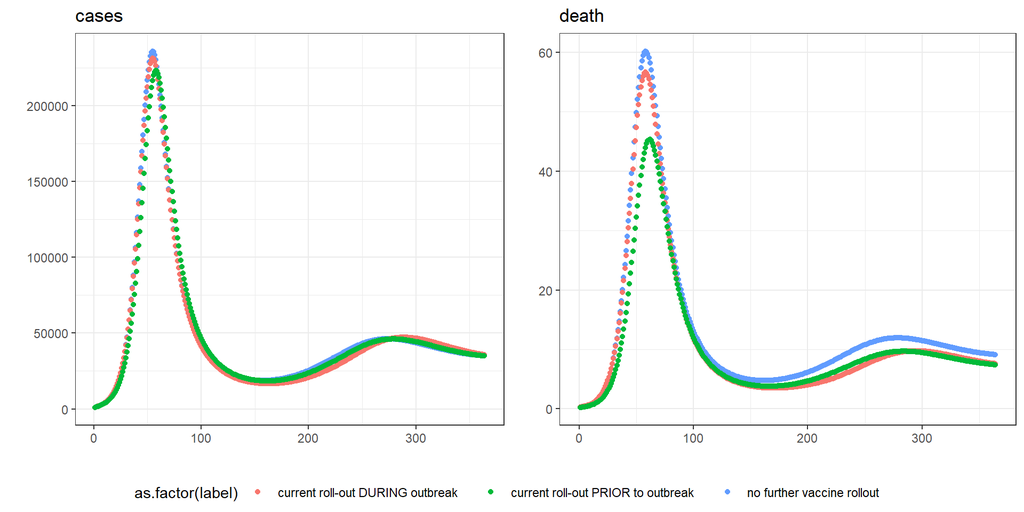

Absolute difference in outcomes (compared to no further vaccine roll-out)

| scenario | death | hosp | severe_disease | YLL | cases |
| --- | --- | --- | --- | --- | --- |
| current roll-out DURING outbreak | 638 | 27,671 | 8,669 | 7,382 | 465,370 |
| current roll-out PRIOR to outbreak | 1,001 | 43,131 | 13,732 | 11,591 | 309,181 |

Relative difference in outcomes

| scenario | death | hosp | severe_disease | YLL | cases |
| --- | --- | --- | --- | --- | --- |
| current roll-out DURING outbreak | 13.40 | 9.37 | 13.13 | 11.80 | 2.57 |
| current roll-out PRIOR to outbreak | 21.03 | 14.61 | 20.80 | 18.53 | 1.71 |

# 3 Varying levels of coverage

## 3.1 Using current age-specific eligiblity

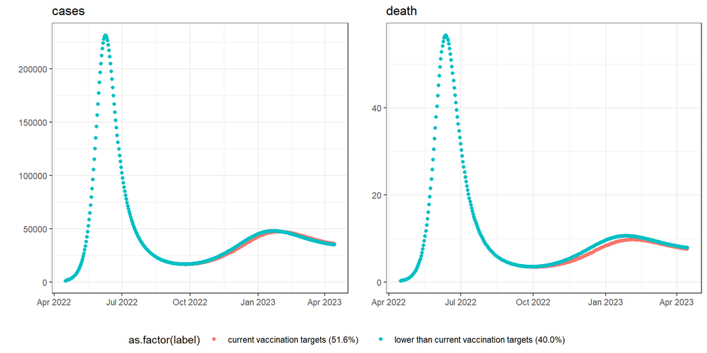

Absolute difference in outcomes (compared to current vaccine targets)

| scenario | death | hosp | severe_disease | YLL | cases |
| --- | --- | --- | --- | --- | --- |
| lower than current vaccination targets (40.0%) | -130 | -5,851 | -1,786 | -1,526 | -130,650 |

Relative difference in outcomes (%)

| scenario | death | hosp | severe_disease | YLL | cases |
| --- | --- | --- | --- | --- | --- |
| lower than current vaccination targets (40.0%) | -3.15 | -2.19 | -3.12 | -2.77 | -0.74 |

## 3.2 Expanding eligibility to children (DURING an outbreak)

### 3.2.1 Run current vaccine campaign, then expand to children

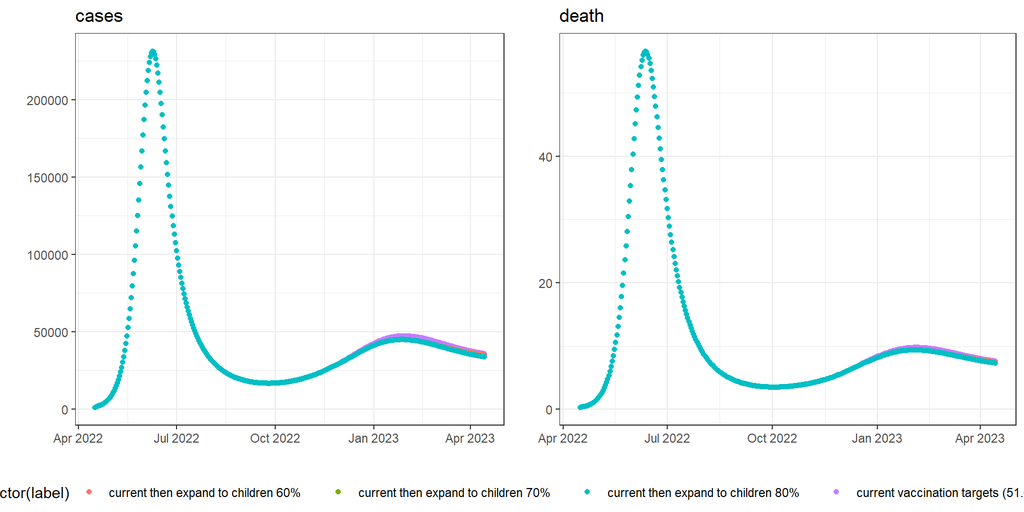

Absolute difference in outcomes (compared to current vaccine targets)

| scenario | death | hosp | severe_disease | YLL | cases |
| --- | --- | --- | --- | --- | --- |
| current then expand to children 60% | 32 | 4,243 | 366 | 579 | 205,653 |
| current then expand to children 70% | 37 | 4,836 | 416 | 658 | 241,240 |
| current then expand to children 80% | 37 | 4,836 | 416 | 658 | 241,240 |

Relative difference in outcomes (%)

| scenario | death | hosp | severe_disease | YLL | cases |
| --- | --- | --- | --- | --- | --- |
| current then expand to children 60% | 0.79 | 1.59 | 0.64 | 1.05 | 1.17 |
| current then expand to children 70% | 0.89 | 1.81 | 0.72 | 1.19 | 1.37 |
| current then expand to children 80% | 0.89 | 1.81 | 0.72 | 1.19 | 1.37 |

### 3.2.2 Expand to children now

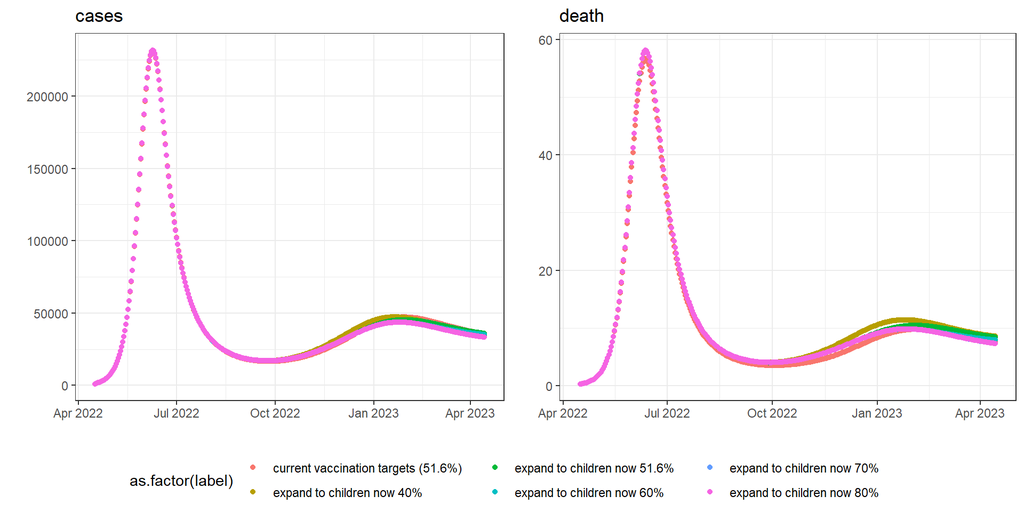

Absolute difference in outcomes (compared to current vaccine targets)

| scenario | death | hosp | severe_disease | YLL | cases |
| --- | --- | --- | --- | --- | --- |
| expand to children now 40% | -368 | -11,833 | -5,097 | -3,966 | -159,281 |
| expand to children now 51.6% | -251 | -4,917 | -3,545 | -2,476 | 47,165 |
| expand to children now 60% | -188 | -1,164 | -2,704 | -1,665 | 206,357 |
| expand to children now 70% | -172 | -195 | -2,489 | -1,459 | 256,312 |
| expand to children now 80% | -172 | -205 | -2,491 | -1,461 | 255,914 |

Relative difference in outcomes (%)

| scenario | death | hosp | severe_disease | YLL | cases |
| --- | --- | --- | --- | --- | --- |
| expand to children now 40% | -8.94 | -4.42 | -8.89 | -7.19 | -0.90 |
| expand to children now 51.6% | -6.10 | -1.84 | -6.18 | -4.49 | 0.27 |
| expand to children now 60% | -4.55 | -0.44 | -4.72 | -3.02 | 1.17 |
| expand to children now 70% | -4.16 | -0.07 | -4.34 | -2.64 | 1.46 |
| expand to children now 80% | -4.17 | -0.08 | -4.34 | -2.65 | 1.45 |

## 3.3 Expanding eligibility to children (PRIOR TO an outbreak)

Note: If waning immunity against severe outcomes ON, this looks like a bad idea.

### 3.3.1 Run current vaccine campaign, then expand to children

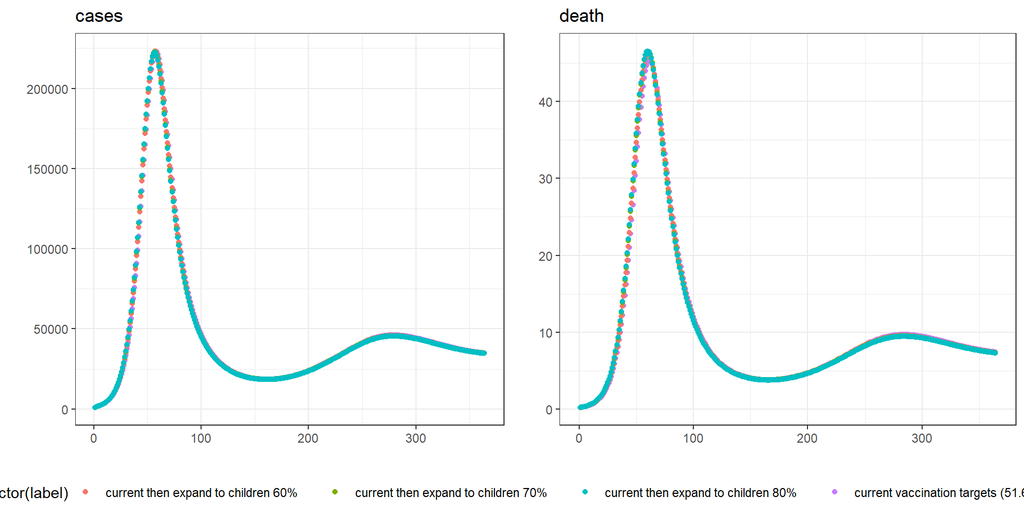

Absolute difference in outcomes (compared to current vaccine targets)

| scenario | death | hosp | severe_disease | YLL | cases |
| --- | --- | --- | --- | --- | --- |
| current then expand to children 60% | -18 | 7,901 | -284 | 444 | 37,955 |
| current then expand to children 70% | -18 | 14,374 | -323 | 932 | 76,336 |
| current then expand to children 80% | -13 | 18,033 | -287 | 1,244 | 100,812 |

Relative difference in outcomes (%)

| scenario | death | hosp | severe_disease | YLL | cases |
| --- | --- | --- | --- | --- | --- |
| current then expand to children 60% | -0.49 | 3.13 | -0.54 | 0.87 | 0.21 |
| current then expand to children 70% | -0.48 | 5.70 | -0.62 | 1.83 | 0.43 |
| current then expand to children 80% | -0.35 | 7.15 | -0.55 | 2.44 | 0.57 |

### 3.3.2 Expand to children now

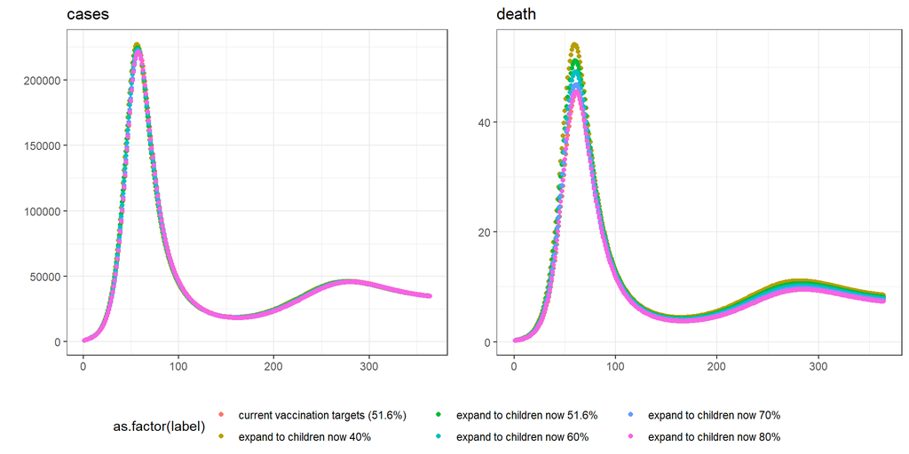

Absolute difference in outcomes (compared to current vaccine targets)

| scenario | death | hosp | severe_disease | YLL | cases |
| --- | --- | --- | --- | --- | --- |
| expand to children now 40% | -633 | -20,728 | -8,762 | -6,842 | -106,620 |
| expand to children now 51.6% | -418 | -7,607 | -5,836 | -4,063 | -21,112 |
| expand to children now 60% | -264 | 1,760 | -3,741 | -2,078 | 33,882 |
| expand to children now 70% | -82 | 12,842 | -1,262 | 270 | 96,889 |
| expand to children now 80% | 17 | 18,898 | 92 | 1,553 | 131,307 |

Relative difference in outcomes (%)

| scenario | death | hosp | severe_disease | YLL | cases |
| --- | --- | --- | --- | --- | --- |
| expand to children now 40% | -16.83 | -8.22 | -16.76 | -13.43 | -0.60 |
| expand to children now 51.6% | -11.11 | -3.02 | -11.16 | -7.97 | -0.12 |
| expand to children now 60% | -7.02 | 0.70 | -7.16 | -4.08 | 0.19 |
| expand to children now 70% | -2.19 | 5.10 | -2.41 | 0.53 | 0.55 |
| expand to children now 80% | 0.45 | 7.50 | 0.18 | 3.05 | 0.74 |

# 4 Varying speed of vaccine roll-out

This section models varying speeds of vaccine roll-out *DURING* an outbreak.

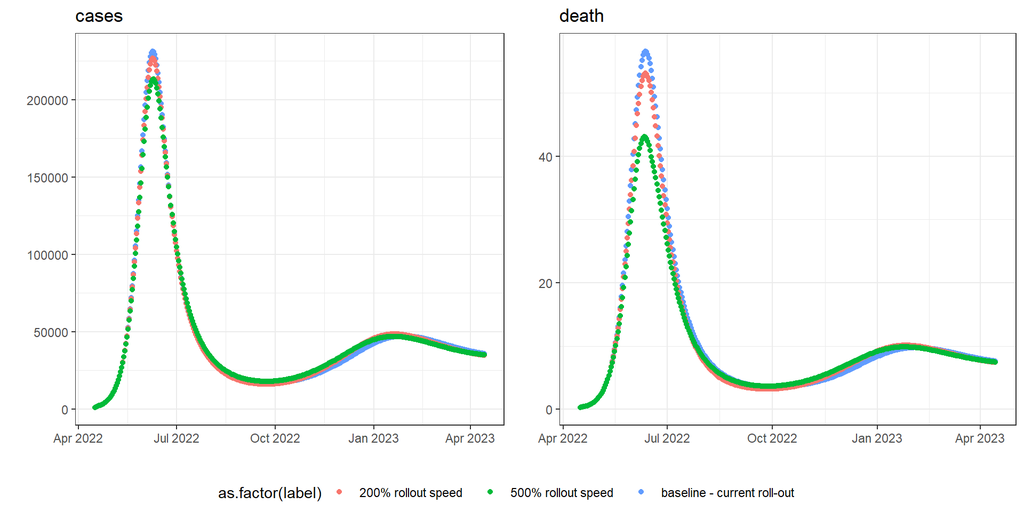

Absolute difference in outcomes (compared to current rollout speed)

| scenario | death | hosp | severe_disease | YLL | cases |
| --- | --- | --- | --- | --- | --- |
| 200% rollout speed | 145 | 5,499 | 1,863 | 1,593 | 11,187 |
| 500% rollout speed | 382 | 14,655 | 4,936 | 4,230 | 54,746 |

Relative difference in outcomes (%)

| scenario | death | hosp | severe_disease | YLL | cases |
| --- | --- | --- | --- | --- | --- |
| 200% rollout speed | 3.51 | 2.06 | 3.25 | 2.89 | 0.06 |
| 500% rollout speed | 9.26 | 5.48 | 8.61 | 7.67 | 0.31 |

# 5 Sensitivity analysis (TBC)

# 6 Appendix

## 6.1 Vaccine effectiveness estimates

### 6.1.1 Point estimates by type, dose and outcome

[figure not shown]

### 6.1.2 Duration of protection (shape of waning immunity)

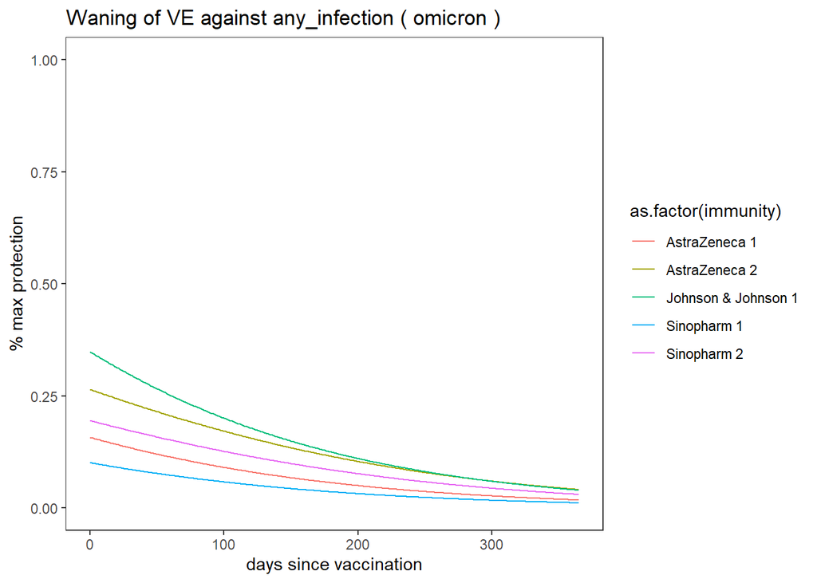

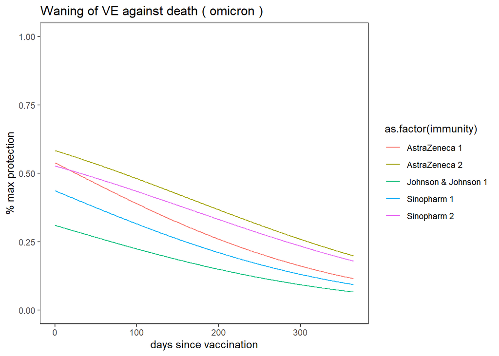

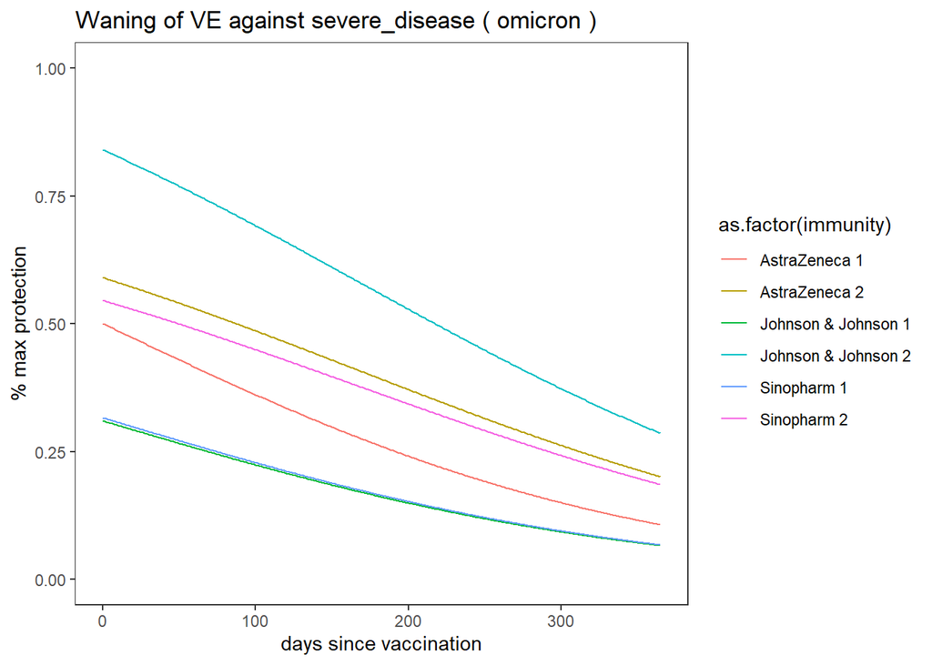

## Infection-derived immunity estimate